## Lesson 01 - ANOVA from UPenn STAT502

```r
#the data - greenhouse data

data <- read.table(file = "lesson1_data.txt", header = T)
head(data)
```

```
##   Control   F1   F2   F3
## 1    21.0 32.0 22.5 28.0
## 2    19.5 30.5 26.0 27.5
## 3    22.5 25.0 28.0 31.0
## 4    21.5 27.5 27.0 29.5
## 5    20.5 28.0 26.5 30.0
## 6    21.0 28.6 25.2 29.2
```

### ONE-WAY ANOVA

One-way ANOVA gets its name from the fact that there’s only one dependent variable to be analysed and one or more independent variables.

Let’s performe the ANOVA on the cholesterol dataset. There are two variables treatments at 5 diferent levels and response variables.

- Independent variables: groups of drug treatment
- Dependent variable: means of two or more groups ANOVA

#### About the dataset

A clinical study was conducted to assess the effect of three formulations of the same drug on reducing cholesterol. The formulations were 20mg at once (1time), 10mg twice a day (2times), and 5mg four times a day (4times). In addition, two competing drugs were used as control group (drugD and drugE). The purpose of the study was to find which of the formulations, if any, is efficacious and how these formulations compare with the existing drugs

```
## 'data.frame':    50 obs. of  2 variables:
##  $ trt     : Factor w/ 5 levels "1time","2times",..: 1 1 1 1 1 1 1 1 1 1 ...
##  $ response: num  3.86 10.39 5.91 3.06 7.72 ...
```

```r
head(cholesterol)
```

```
##     trt response
## 1 1time   3.8612
## 2 1time  10.3868
## 3 1time   5.9059
## 4 1time   3.0609
## 5 1time   7.7204
## 6 1time   2.7139
```

#Analysis of Variance Model

```r
attach(cholesterol)
aov_model <- aov(response ~ trt)
summary(aov_model)
```

```
##             Df Sum Sq Mean Sq F value   Pr(>F)
## trt          4 1351.4   337.8   32.43 9.82e-13 ***
## Residuals   45  468.8    10.4
## ---
## Signif. codes:  0 '***' 0.001 '**' 0.01 '*' 0.05 '.' 0.1 ' ' 1
```

Keep in mind that R does a F-test with a 95%CI, it means that if our p-value is less than 5%, than we can reject the null in favor of the alternative that there’s difference between the mean of the different treatment groups.

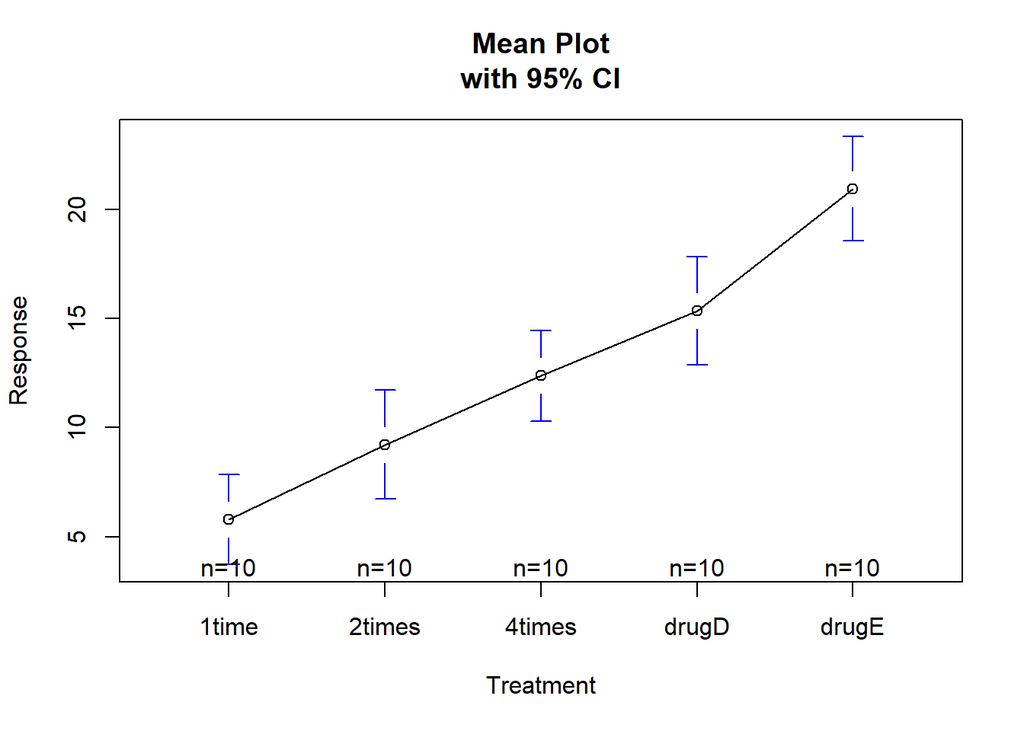

```r
plotmeans(response ~ trt, xlab = "Treatment", ylab = "Response",
          main = "Mean Plot\nwith 95% CI")
```

The ONE-WAY ANOVA test tells us **if the difference between the mean groups is statistically significant**.

In this case, we can conclude that there’s difference between the treatment means.

### Tukey’s Test

The Tukey’s test is a *post hoc test* (multiple comparison test) done when we want to do pair-wise comparison between different treatment groups. It tells us **which exactly groups are different from each other**

```r
#Tukey test for the cholesterol data
TukeyHSD(aov_model, conf.level = 0.95)
```

```
##   Tukey multiple comparisons of means
##     95% family-wise confidence level
##
## Fit: aov(formula = response ~ trt)
##
## $trt
##                   diff        lwr       upr     p adj
## 2times-1time   3.44300 -0.6582817  7.544282 0.1380949
## 4times-1time   6.59281  2.4915283 10.694092 0.0003542
## drugD-1time    9.57920  5.4779183 13.680482 0.0000003
## drugE-1time   15.16555 11.0642683 19.266832 0.0000000
## 4times-2times  3.14981 -0.9514717  7.251092 0.2050382
## drugD-2times   6.13620  2.0349183 10.237482 0.0009611
## drugE-2times  11.72255  7.6212683 15.823832 0.0000000
## drugD-4times   2.98639 -1.1148917  7.087672 0.2512446
## drugE-4times   8.57274  4.4714583 12.674022 0.0000037
## drugE-drugD    5.58635  1.4850683  9.687632 0.0030633
```

We can vizualize the 95% difference intervals form the Tukey-test

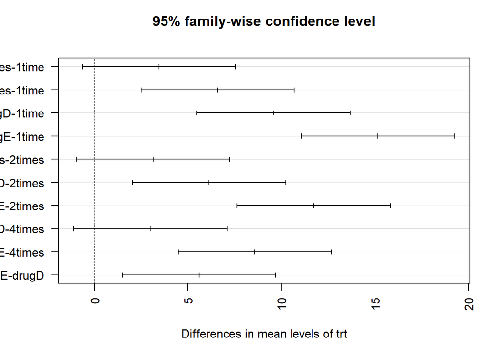

```r
plot(TukeyHSD(aov_model, conf.level = 0.95), las = 2)
```

```r
par(mar=c(5,8,8,10))
par(c("mar", "mei"))
```

```
## $mar
## [1]  5  8  8 10
##
## $mei
## NULL
```

If the interval contains zero, than we know that the difference among the treatment groups are not significant. Likewise, if the p-value is greater than $\alpha$ than we know that there’s no significant difference among the treatment groups.

## Tukey- Test using the `multcompView` library

```r
#Create data
set.seed(1)
treatment <- rep(c("A", "B", "C", "D", "E"), each=20)
value=c( sample(2:5, 20 , replace=T) , sample(6:10, 20 , replace=T), sample(1:7, 20 , replace=T), sample(3:10, 20 , replace=T) , sample(10:20, 20 , replace=T) )
data=data.frame(treatment,value)
head(data)
```

```
##   treatment value
## 1         A     2
## 2         A     5
## 3         A     4
## 4         A     2
## 5         A     3
## 6         A     2
```

```r
#creating the model
model = lm(data$value ~ data$treatment)
anova=aov(model)

summary(anova)
```

```
##                Df Sum Sq Mean Sq F value Pr(>F)
## data$treatment  4 1651.2   412.8   85.34 <2e-16 ***
## Residuals      95  459.6     4.8
## ---
## Signif. codes:  0 '***' 0.001 '**' 0.01 '*' 0.05 '.' 0.1 ' ' 1
```

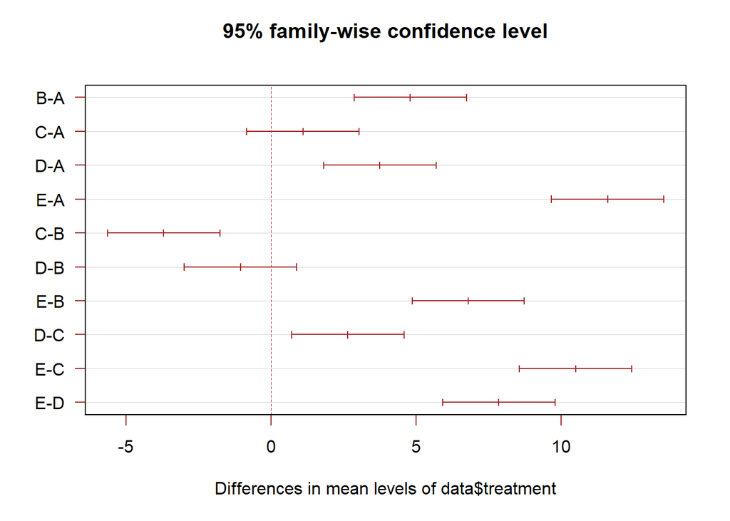

```r
#tukey test

tukey <- TukeyHSD(anova, 'data$treatment', conf.level = 0.95)

#tukey test representation
plot(tukey, las = 1, col = 'brown')
```

The family-wise interval showed us that there’s no difference between the groups:

- C-A
- D-B

Because the intervals contain the number 0 (???)